# Exponential Smoothing

2024-02-27

## What is Exponential Smoothing:

- Exponential Smoothing was proposed in the late 1950s by Brown, Holts and Winter
- Exponential Smoothing are weighted averages of past observations, with the weights decaying exponentially as the observations get older.
- In other words, the more recent the observation the higher the associated weight.
- There are many variations of exponential smoothing, we will talk about a few of them.

## What is Exponential Smoothing:

Some data exhibits no clear seasonality or trend, rendering certain techniques useless.

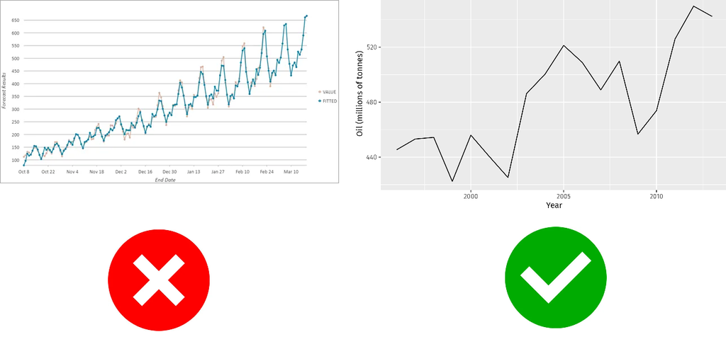

## Simple Exponential Smoothing (SES)

- Simple Exponential Smoothing is considered the simplest of exponential smoothing methods
- It is usually used to forecast data with no clear trend or seasonal pattern
- Forecast Equation : \(\hat{y}_{T+1|T} = \alpha y_T + \alpha(1-\alpha)y_{T-1} + \alpha(1-\alpha)^2y_{T-2} +...\)

## Simple Exponential Smoothing (cont.)

- It has a single parameter
- Alpha is often set to a value between 0 and 1.
- Large values mean that the model pays attention mainly to the most recent past observations, whereas smaller values mean more of the history is taken into account when making a prediction.

## Example: Algeria GDP

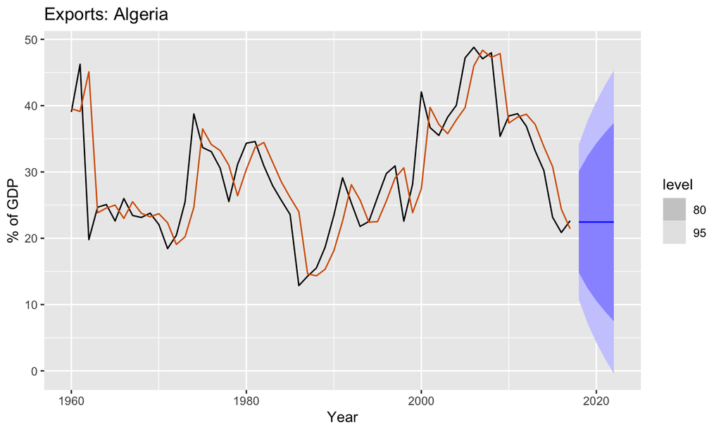

## Example: Algeria GDP

```r
algeria_economy <- global_economy |>
  filter(Country == "Algeria")

fit <- algeria_economy %>%
  model( `SES` = ETS(Exports ~ error("A") + trend("N") + season("N") ))

fc <- fit %>%
  forecast( h = 5)
```

## Double Exponential Smoothing

- Holt’s had extended simple exponential smoothing to allow forecasting of the data with a trend aka Holt’s Linear Trend Model

This method support two types of trends:

- Additive Trend: Double Exponential Smoothing with a linear trend.
- Multiplicative Trend: Double Exponential Smoothing with an exponential trend.

## Forecast Equation

Forecast Equation: \(\hat{y}_{t+h|t} = l_t +hb_t\)

Level equation: \(l_t = \alpha y_t +( 1-\alpha) ( l_{t-1} +b_{t-1})\)

Trend equation: \(b_t = \beta^* ( l_t - t_{t-1}) + (1 - \beta^*)b_{t-1}\)

- Two smoothing parameters \(\alpha\) and \(\beta^*\).
- \(l_t\) level: Weighted average between \(y_t\) and one step above forecast.
- Choose parameters to minimize the SSE.

## Example: Australia Population

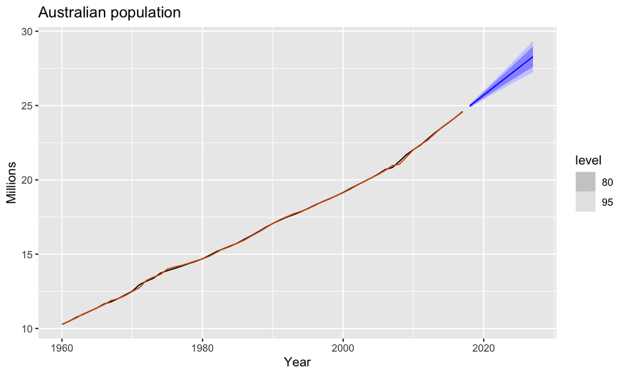

## Example: Australia Population

```r
fit <- aus_economy %>%
  model(  `Double Exponential` = ETS(Pop ~ error("A") + trend("A") + season("N")))
fc <- fit |> forecast(h = 10)
```

## Example: Australia Population

```
## Series: Pop
## Model: ETS(A,A,N)
##   Smoothing parameters:
##     alpha = 0.9999
##     beta  = 0.3266366
##
##   Initial states:
##      l[0]      b[0]
##  10.05414 0.2224818
##
##   sigma^2:  0.0041
##
##       AIC      AICc       BIC
## -76.98569 -75.83184 -66.68347
```

## Dampening

- In cases of longer range (multi-step) forecasts, the trend may continue on indefinitely into the future.
- Gardner and Mckenzie introduced a parameter that “dampens” the trend to a flat line some time into the future i.e (Dampened Holt).

## Dampening (cont.)

Forecast Equation: \(\hat{y}_{t+h|t} = l_t + \boldsymbol{(\phi + \phi^2 + ... +\phi^h)} b_t\)

Level equation: \(l_t = \alpha y_t +(1-\alpha )(l_{t-1} + \boldsymbol{\phi} b_{t-1})\)

Trend equation: \(b_t = (l_t - l_{t-1}) + (1-\beta^*)\boldsymbol{\phi} b_{t-1}\)

- For values between 0 and 1 phi dampens the trend so that it approaches a constant some time in the future
- As h approaches infinity short-run forecasts are trended and the long-run forecasts are constant

## Dampening Example

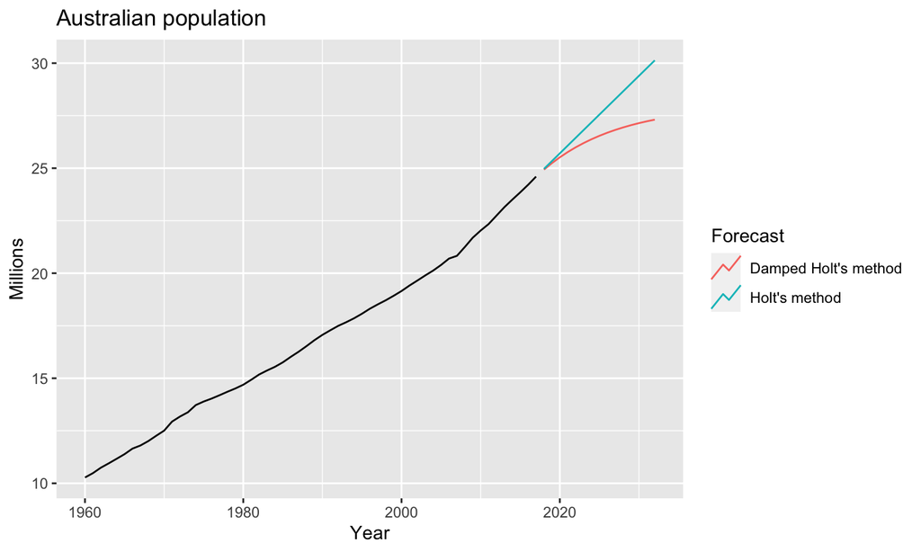

## Triple Exponential Smoothing

Holt and Winters extended Holt’s Linear Trend Model to include seasonality this is sometimes known as Holt-Winter Exponential Smoothing.

Forecast Equation: \(\hat{y}_{t+h|t} = l_t + hb_t + s_{t+h-m(k+1)}\)

Level Equation: \(l_t = \alpha( y_t -s_{t-m} ) + (1-\alpha)(l_{t-1} + b_{t-1})\)

Trend Equation: \(b_t = \beta^* ( l_t- l_{t-1}) +(1-\beta^*)b_{t-1}\)

Seasonal Component: \(s_t = \gamma( y_t - l_{t-1} - b_{t-1}) + (1-\gamma) s_{t-m}\)

Where \(\gamma\) is the smoothing coefficient dor the seasonal component and \(m\) is the period of seasonality.

## Triple Exponential Smoothing with Dampening

- Damping is also possible with triple exponential smoothing
- There is an additive and multiplicative method for Holt-Winters’
- A method that often provides accurate and robust forecasts for seasonal data is the Holt-Winters method with a damped trend and multiplicative seasonality

## Triple Exponential Smoothing Example : Australia Holidays

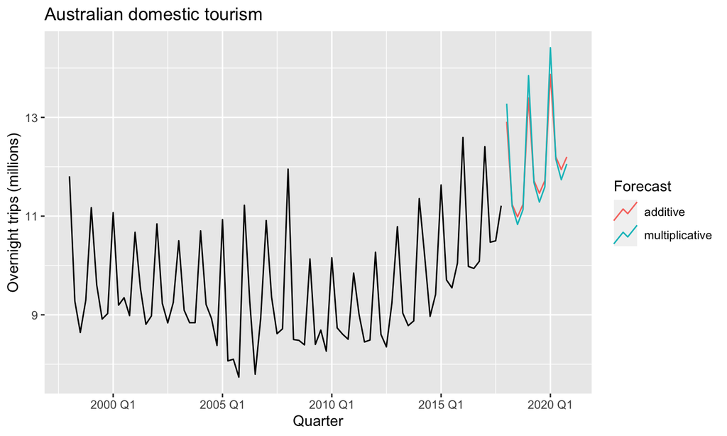

## Triple Exponential Smoothing Example : Australia Holidays

```r
fit <- aus_holidays |>
  model(
    additive = ETS(Trips ~ error("A") + trend("A") +
                                                season("A")),
    multiplicative = ETS(Trips ~ error("M") + trend("A") +
                                                season("M"))
  )
fc <- fit |> forecast(h = "3 years")
```

## Different ETS Models

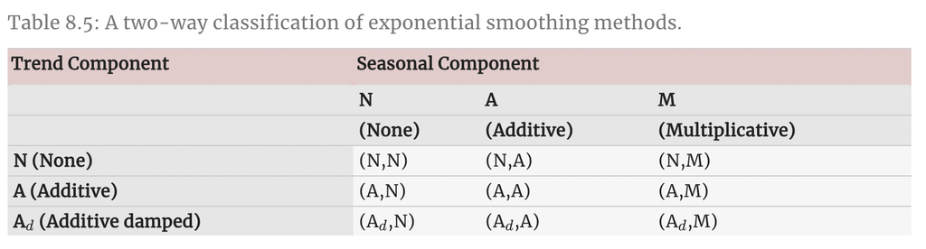

## Different ETS Models (cont.)

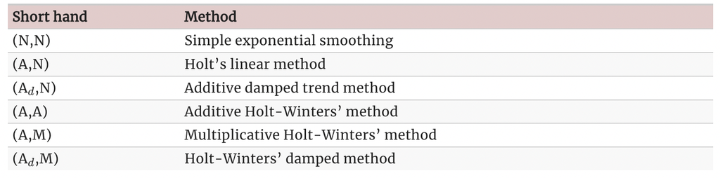

## Different ETS Models (cont.)

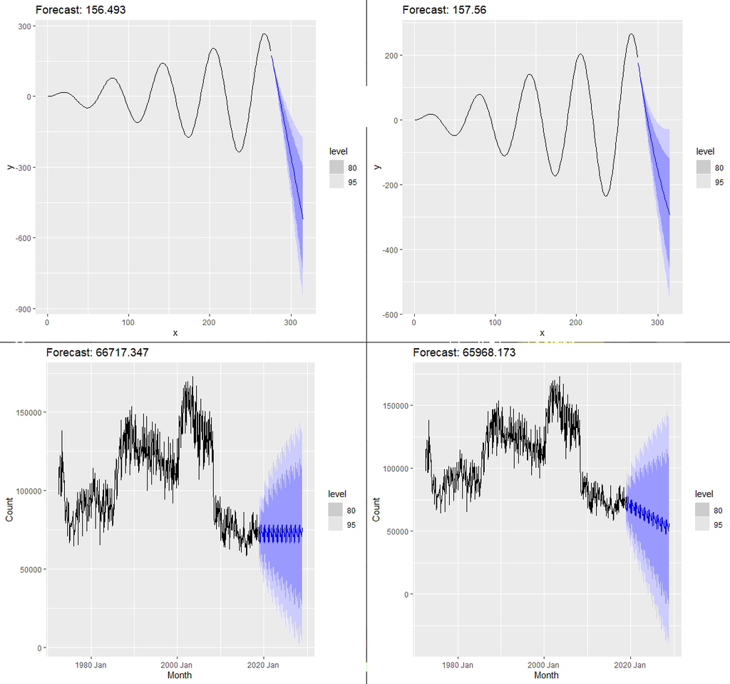